# Análisis Exploratorio de Datos (EDA) y Preparación K-Means

### 2. Del tamaño del capítulo a su concentración

`participacion` ya indica el peso de cada capítulo dentro de las importaciones del mismo año. Se compara con el HHI: un capítulo muy concentrado pero pequeño cuenta una historia diferente a uno que combina alto valor y concentración. Para evitar basar una conclusión en un solo año, se contrastan promedios de 2015–2017 y 2023–2025.

```r
perfil_hs2 <- indicadores %>%
  filter(flow_code == "M") %>%
  group_by(hs2) %>%
  summarise(
    capitulo = first(capitulo),
    años_observados = n_distinct(año),
    años_inicio = sum(año %in% 2015:2017),
    años_fin = sum(año %in% 2023:2025),
    hhi_medio = mean(hhi),
    hhi_inicio = mean(hhi[año %in% 2015:2017]),
    hhi_fin = mean(hhi[año %in% 2023:2025]),
    participacion_media = mean(participacion),
    participacion_inicio = mean(participacion[año %in% 2015:2017]),
    participacion_fin = mean(participacion[año %in% 2023:2025]),
    .groups = "drop"
  ) %>%
  filter(años_observados >= 8, años_inicio == 3, años_fin == 3) %>%
  mutate(cambio_hhi = hhi_fin - hhi_inicio,
         cambio_peso_pp = 100 * (participacion_fin - participacion_inicio))

knitr::kable(perfil_hs2 %>% arrange(desc(cambio_hhi)) %>%
               select(hs2, capitulo, hhi_inicio, hhi_fin,
                      cambio_hhi, participacion_fin) %>% head(10),
             digits = 3, caption = "Capítulos con mayor aumento del HHI importador")
```

Capítulos con mayor aumento del HHI importador

| hs2 | capitulo | hhi_inicio | hhi_fin | cambio_hhi | participacion_fin |
| --- | --- | --- | --- | --- | --- |
| 14 | Vegetable plaiting materials; vegetable products not elsewhere specified or included | 0.170 | 0.492 | 0.323 | 0.000 |
| 26 | Ores, slag and ash | 0.179 | 0.415 | 0.236 | 0.003 |
| 67 | Feathers and down, prepared; and articles made of feather or of down; artificial flowers; articles of human hair | 0.668 | 0.892 | 0.224 | 0.000 |
| 91 | Clocks and watches and parts thereof | 0.359 | 0.541 | 0.181 | 0.001 |
| 50 | Silk | 0.256 | 0.416 | 0.160 | 0.000 |
| 24 | Tobacco and manufactured tobacco substitutes | 0.360 | 0.520 | 0.159 | 0.000 |
| 93 | Arms and ammunition; parts and accessories thereof | 0.212 | 0.361 | 0.149 | 0.000 |
| 89 | Ships, boats and floating structures | 0.342 | 0.458 | 0.116 | 0.000 |
| 75 | Nickel and articles thereof | 0.340 | 0.437 | 0.097 | 0.001 |
| 27 | Mineral fuels, mineral oils and products of their distillation; bituminous substances; mineral waxes | 0.743 | 0.838 | 0.095 | 0.068 |

```r
knitr::kable(perfil_hs2 %>% arrange(cambio_hhi) %>%
               select(hs2, capitulo, hhi_inicio, hhi_fin,
                      cambio_hhi, participacion_fin) %>% head(10),
             digits = 3, caption = "Capítulos con mayor reducción del HHI importador")
```

Capítulos con mayor reducción del HHI importador

| hs2 | capitulo | hhi_inicio | hhi_fin | cambio_hhi | participacion_fin |
| --- | --- | --- | --- | --- | --- |
| 57 | Carpets and other textile floor coverings | 0.481 | 0.243 | -0.238 | 0.000 |
| 56 | Wadding, felt and nonwovens, special yarns; twine, cordage, ropes and cables and articles thereof | 0.564 | 0.330 | -0.235 | 0.002 |
| 59 | Textile fabrics; impregnated, coated, covered or laminated; textile articles of a kind suitable for industrial use | 0.562 | 0.341 | -0.221 | 0.002 |
| 79 | Zinc and articles thereof | 0.453 | 0.242 | -0.211 | 0.000 |
| 17 | Sugars and sugar confectionery | 0.766 | 0.572 | -0.194 | 0.003 |
| 05 | Animal originated products; not elsewhere specified or included | 0.761 | 0.577 | -0.184 | 0.001 |
| 95 | Toys, games and sports requisites; parts and accessories thereof | 0.549 | 0.368 | -0.182 | 0.005 |
| 11 | Products of the milling industry; malt, starches, inulin, wheat gluten | 0.577 | 0.398 | -0.179 | 0.001 |
| 37 | Photographic or cinematographic goods | 0.428 | 0.251 | -0.177 | 0.000 |
| 71 | Natural, cultured pearls; precious, semi-precious stones; precious metals, metals clad with precious metal, and articles thereof; imitation jewellery; coin | 0.322 | 0.160 | -0.163 | 0.003 |

```r
knitr::kable(perfil_hs2 %>% arrange(desc(abs(cambio_peso_pp))) %>%
               select(hs2, capitulo, participacion_inicio,
                      participacion_fin, cambio_peso_pp) %>% head(10),
             digits = 3,
             caption = "Mayores cambios absolutos de peso (puntos porcentuales)")
```

Mayores cambios absolutos de peso (puntos porcentuales)

| hs2 | capitulo | participacion_inicio | participacion_fin | cambio_peso_pp |
| --- | --- | --- | --- | --- |
| 99 | Commodities not specified according to kind | 0.033 | 0.045 | 1.235 |
| 84 | Nuclear reactors, boilers, machinery and mechanical appliances; parts thereof | 0.171 | 0.183 | 1.148 |
| 90 | Optical, photographic, cinematographic, measuring, checking, medical or surgical instruments and apparatus; parts and accessories | 0.037 | 0.028 | -0.905 |
| 72 | Iron and steel | 0.023 | 0.031 | 0.723 |
| 39 | Plastics and articles thereof | 0.056 | 0.049 | -0.712 |
| 85 | Electrical machinery and equipment and parts thereof; sound recorders and reproducers; television image and sound recorders and reproducers, parts and accessories of such articles | 0.213 | 0.206 | -0.697 |
| 73 | Iron or steel articles | 0.023 | 0.018 | -0.470 |
| 27 | Mineral fuels, mineral oils and products of their distillation; bituminous substances; mineral waxes | 0.072 | 0.068 | -0.449 |
| 29 | Organic chemicals | 0.020 | 0.017 | -0.333 |
| 87 | Vehicles; other than railway or tramway rolling stock, and parts and accessories thereof | 0.097 | 0.100 | 0.301 |

- HS84, maquinaria mecánica, pasó de representar aproximadamente 17.1 % a 18.3 % de las importaciones: ganó 1.148 puntos porcentuales. Este dato confirma que HS84 es importante y debe aparecer cuando corrijas la tabla comparativa de HHI.
- HS85, equipo eléctrico, perdió 0.697 puntos porcentuales, pero siguió siendo el capítulo de mayor peso entre los mostrados: 20.6 % en el periodo final. Juntos, HS84 y HS85 representan aproximadamente 38.9 %.

Además del HHI, esta tabla muestra si cambió el país que tenía la cuota más alta en cada capítulo. El cambio de líder no prueba por sí solo que todos los demás proveedores hayan cambiado.

```r
cambio_lider <- indicadores %>%
  filter(flow_code == "M", año %in% c(2015, 2025)) %>%
  select(año, hs2, socio_principal, top1, valor_usd) %>%
  pivot_wider(names_from = año,
              values_from = c(socio_principal, top1, valor_usd)) %>%
  filter(!is.na(socio_principal_2015), !is.na(socio_principal_2025)) %>%
  mutate(cambio_de_lider = socio_principal_2015 != socio_principal_2025) %>%
  arrange(desc(valor_usd_2025))
knitr::kable(cambio_lider %>% head(15), digits = 3,
             caption = "Proveedor principal en 2015 y 2025 para los capítulos de mayor valor en 2025")
```

Proveedor principal en 2015 y 2025 para los capítulos de mayor valor en 2025

| hs2 | socio_principal_2015 | socio_principal_2025 | top1_2015 | top1_2025 | valor_usd_2015 | valor_usd_2025 | cambio_de_lider |
| --- | --- | --- | --- | --- | --- | --- | --- |
| 84 | USA | USA | 0.397 | 0.245 | 67685896944 | 144474585274 | FALSE |
| 85 | China | China | 0.338 | 0.322 | 85413675736 | 139747265525 | FALSE |
| 87 | USA | USA | 0.531 | 0.388 | 37266625012 | 62732602616 | FALSE |
| 27 | USA | USA | 0.842 | 0.933 | 26455515248 | 36996200959 | FALSE |
| 39 | USA | USA | 0.692 | 0.609 | 22308496453 | 30703144257 | FALSE |
| 99 | USA | USA | 0.368 | 0.375 | 11703403716 | 28290698387 | FALSE |
| 90 | USA | USA | 0.368 | 0.439 | 14989763051 | 18479894427 | FALSE |
| 72 | USA | USA | 0.442 | 0.387 | 9406974542 | 16362694975 | FALSE |
| 76 | USA | USA | 0.562 | 0.328 | 5481953514 | 10571345489 | FALSE |
| 73 | USA | USA | 0.522 | 0.471 | 9386558048 | 10422586532 | FALSE |
| 29 | USA | USA | 0.601 | 0.577 | 8075484409 | 10131290401 | FALSE |
| 30 | USA | USA | 0.296 | 0.230 | 4804125675 | 10078507828 | FALSE |
| 02 | USA | USA | 0.825 | 0.659 | 3820538832 | 9116591063 | FALSE |
| 40 | USA | USA | 0.473 | 0.395 | 6565063892 | 8461094314 | FALSE |
| 10 | USA | USA | 0.868 | 0.896 | 4005357279 | 8179909620 | FALSE |

Entre los capítulos de mayor valor importado en 2025, no se observó un cambio de proveedor principal al comparar 2015 con 2025. Sin embargo, sí cambió cuánto valor concentraba ese proveedor. La cuota del líder disminuyó notablemente en maquinaria mecánica, vehículos y aluminio, mientras que aumentó en combustibles. Por ello, la permanencia de un país en primer lugar no implica que la concentración comercial permanezca constante.

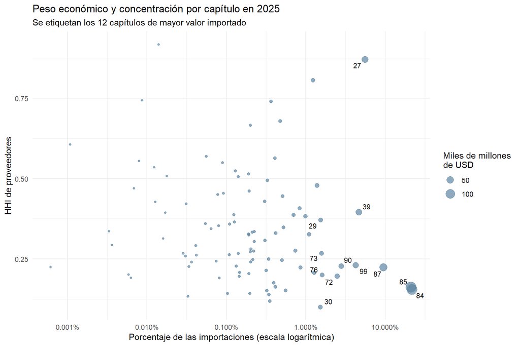

```r
vista_2025 <- indicadores %>% filter(año == 2025, flow_code == "M")
etiquetas_2025 <- vista_2025 %>% slice_max(valor_usd, n = 12)
ggplot(vista_2025, aes(participacion, hhi, size = valor_usd / 1e9)) +
  geom_point(color = "#537d9b", alpha = 0.65) +
  ggrepel::geom_text_repel(data = etiquetas_2025, aes(label = hs2),
                           size = 3, show.legend = FALSE) +
  scale_x_log10(labels = scales::percent) +
  labs(title = "Peso económico y concentración por capítulo en 2025",
       subtitle = "Se etiquetan los 12 capítulos de mayor valor importado",
       x = "Porcentaje de las importaciones (escala logarítmica)",
       y = "HHI de proveedores", size = "Miles de millones\nde USD") +
  theme_minimal()
```

Arriba y a la derecha están los capítulos que combinan mayor concentración y participación. La ubicación no demuestra riesgo de desabasto: el HHI mide valor, no cantidades físicas ni facilidad de cambiar de proveedor. Las variaciones nominales también pueden reflejar precios.

En 2025, los capítulos de mayor valor importado no fueron necesariamente los más concentrados. Maquinaria mecánica (HS84) y equipo eléctrico (HS85) tuvieron un HHI relativamente bajo con las etiquetas originales. Combustibles (HS27) combinó un valor importante con alta concentración. El HHI de HS84 y HS85 se revisa más adelante porque parte de su valor corresponde a etiquetas de socio no específicas.

### 3. Preparación de datos para el modelo

La unidad del modelo es el **capítulo HS2 de importaciones**: cada fila resume su comportamiento entre 2015 y 2025. Antes de agruparlos, revisamos la cobertura temporal y las etiquetas que no identifican un país. El capítulo HS99 se conserva en el análisis descriptivo, pero se excluye del agrupamiento porque reúne mercancías sin una categoría de producto especificada.

Etiquetas de socios no especificados en importaciones

| partnerCode | partnerDesc | registros | valor_usd |
| --- | --- | --- | --- |
| 490 | Other Asia, nes | 810 | 152531765871 |
| 899 | Areas, nes | 1067 | 23593381188 |
| 568 | Other Europe, nes | 396 | 1161900955 |
| 637 | North America and Central America, nes | 1 | 447 |

Cobertura temporal de los capítulos candidatos

| años_observados | capitulos |
| --- | --- |
| 11 | 97 |

Peso anual de las etiquetas de socio no especificado

| año | valor_total_usd | valor_no_especificado_usd | porcentaje_no_especificado |
| --- | --- | --- | --- |
| 2015 | 395253856855 | 7364809003 | 1.86 |
| 2016 | 387087412856 | 7583133426 | 1.96 |
| 2017 | 420394590810 | 8317612928 | 1.98 |
| 2018 | 464294259444 | 9080781982 | 1.96 |
| 2019 | 455235784381 | 10305468557 | 2.26 |
| 2020 | 382979895758 | 9363797580 | 2.44 |
| 2021 | 505715615701 | 14825571130 | 2.93 |
| 2022 | 606295621090 | 19283708309 | 3.18 |
| 2023 | 605582537052 | 18596480289 | 3.07 |
| 2024 | 636780456443 | 21691972802 | 3.41 |
| 2025 | 663605567587 | 50873712455 | 7.67 |

Capítulos con más valor atribuido a esas etiquetas en 2025

| año | hs2 | valor_total_usd | valor_no_especificado_usd | porcentaje_no_especificado |
| --- | --- | --- | --- | --- |
| 2025 | 84 | 144474585274 | 32434904019 | 22.45 |
| 2025 | 85 | 139747265525 | 11003917411 | 7.87 |
| 2025 | 99 | 28290698387 | 659307040 | 2.33 |
| 2025 | 27 | 36996200959 | 585172578 | 1.58 |
| 2025 | 72 | 16362694975 | 500600468 | 3.06 |
| 2025 | 26 | 1999719404 | 437890127 | 21.90 |
| 2025 | 39 | 30703144257 | 408876725 | 1.33 |
| 2025 | 73 | 10422586532 | 401681382 | 3.85 |
| 2025 | 90 | 18479894427 | 366182632 | 1.98 |
| 2025 | 31 | 2274688904 | 336626800 | 14.80 |
| 2025 | 87 | 62732602616 | 256020965 | 0.41 |
| 2025 | 25 | 936459110 | 218652792 | 23.35 |
| 2025 | 10 | 8179909620 | 201042992 | 2.46 |
| 2025 | 28 | 3372087762 | 176809393 | 5.24 |
| 2025 | 15 | 2328829523 | 155176963 | 6.66 |

Sensibilidad del HHI y del socio principal a etiquetas no específicas

| año | hs2 | capitulo | valor_usd | hhi_original | top1_original | socio_principal_original | hhi_sin | top1_sin | socio_principal_sin | valor_usd_sin | porcentaje_no_especificado | diferencia_hhi | diferencia_top1_pp |
| --- | --- | --- | --- | --- | --- | --- | --- | --- | --- | --- | --- | --- | --- |
| 2015 | 27 | Mineral fuels, mineral oils and products of their distillation; bituminous substances; mineral waxes | 26455515248 | 0.715 | 0.842 | USA | 0.731 | 0.851 | USA | 26164387626 | 1.100 | 0.016 | 0.936 |
| 2024 | 27 | Mineral fuels, mineral oils and products of their distillation; bituminous substances; mineral waxes | 41002444376 | 0.852 | 0.922 | USA | 0.869 | 0.932 | USA | 40592327198 | 1.000 | 0.017 | 0.932 |
| 2025 | 27 | Mineral fuels, mineral oils and products of their distillation; bituminous substances; mineral waxes | 36996200959 | 0.870 | 0.933 | USA | 0.899 | 0.948 | USA | 36411028381 | 1.582 | 0.028 | 1.499 |
| 2015 | 84 | Nuclear reactors, boilers, machinery and mechanical appliances; parts thereof | 67685896944 | 0.223 | 0.397 | USA | 0.228 | 0.402 | USA | 66855553092 | 1.227 | 0.005 | 0.493 |
| 2024 | 84 | Machinery and mechanical appliances, boilers, nuclear reactors; parts thereof | 109688739817 | 0.171 | 0.321 | USA | 0.187 | 0.339 | USA | 103878013111 | 5.297 | 0.017 | 1.794 |
| 2025 | 84 | Machinery and mechanical appliances, boilers, nuclear reactors; parts thereof | 144474585274 | 0.155 | 0.245 | USA | 0.174 | 0.316 | USA | 112039681255 | 22.450 | 0.019 | 7.105 |
| 2015 | 85 | Electrical machinery and equipment and parts thereof; sound recorders and reproducers; television image and sound recorders and reproducers, parts and accessories of such articles | 85413675736 | 0.204 | 0.338 | China | 0.219 | 0.351 | China | 82189670627 | 3.775 | 0.015 | 1.325 |
| 2024 | 85 | Electrical machinery and equipment and parts thereof; sound recorders and reproducers; television image and sound recorders and reproducers, parts and accessories of such articles | 131176317049 | 0.172 | 0.326 | China | 0.193 | 0.350 | China | 122207370720 | 6.837 | 0.021 | 2.393 |
| 2025 | 85 | Electrical machinery and equipment and parts thereof; sound recorders and reproducers; television image and sound recorders and reproducers, parts and accessories of such articles | 139747265525 | 0.163 | 0.322 | China | 0.185 | 0.349 | China | 128743348114 | 7.874 | 0.022 | 2.751 |

La prueba de sensibilidad muestra que la concentración de HS84 y HS85 sigue disminuyendo al restringir los cálculos a socios identificados, aunque la magnitud cambia. En 2025, las etiquetas no específicas representan 22.45 % del valor importado en HS84. Por ello, el modelo usa indicadores recalculados entre socios identificados y conserva los indicadores originales para contrastar resultados. La exclusión no convierte ese valor en cero ni lo reasigna a otro país.

La participación del modelo tiene como denominador el valor importado asignado a socios identificados de cada año. Para interpretar el resultado se conserva también la cobertura del valor original.

Capítulos con menor cobertura de socios identificados en 2025

| año | hs2 | valor_total_usd | valor_identificado_usd | cobertura_identificada |
| --- | --- | --- | --- | --- |
| 2025 | 24 | 52834276 | 17630455 | 0.334 |
| 2025 | 93 | 112515183 | 49612336 | 0.441 |
| 2025 | 80 | 222277449 | 141768817 | 0.638 |
| 2025 | 78 | 84638936 | 55412797 | 0.655 |
| 2025 | 01 | 272160597 | 189775659 | 0.697 |
| 2025 | 51 | 41563117 | 29725325 | 0.715 |
| 2025 | 25 | 936459110 | 717806318 | 0.767 |
| 2025 | 43 | 4052695 | 3114269 | 0.768 |
| 2025 | 50 | 7183316 | 5531927 | 0.770 |
| 2025 | 36 | 189479077 | 146771945 | 0.775 |

Capítulos de mayor peso preparados para K-means

| hs2 | capitulo | hhi_medio | cambio_hhi | participacion_media | cambio_peso_pp | peso_log |
| --- | --- | --- | --- | --- | --- | --- |
| 85 | Electrical machinery and equipment and parts thereof; sound recorders and reproducers; television image and sound recorders and reproducers, parts and accessories of such articles | 0.203 | -0.030 | 0.202 | -0.718 | 3.054 |
| 84 | Machinery and mechanical appliances, boilers, nuclear reactors; parts thereof | 0.208 | -0.031 | 0.167 | -0.266 | 2.876 |
| 87 | Vehicles; other than railway or tramway rolling stock, and parts and accessories thereof | 0.255 | -0.061 | 0.095 | 0.612 | 2.348 |
| 27 | Mineral fuels, mineral oils and products of their distillation; bituminous substances; mineral waxes | 0.815 | 0.100 | 0.080 | -0.280 | 2.201 |
| 39 | Plastics and articles thereof | 0.445 | -0.074 | 0.055 | -0.581 | 1.870 |
| 90 | Optical, photographic, cinematographic, measuring, checking, medical or surgical instruments and apparatus; parts and accessories | 0.232 | 0.021 | 0.034 | -0.727 | 1.480 |
| 72 | Iron and steel | 0.209 | -0.056 | 0.028 | 0.811 | 1.332 |
| 73 | Iron or steel articles | 0.309 | -0.036 | 0.020 | -0.393 | 1.114 |
| 29 | Organic chemicals | 0.373 | 0.023 | 0.020 | -0.302 | 1.087 |
| 76 | Aluminium and articles thereof | 0.250 | -0.105 | 0.016 | 0.251 | 0.953 |

```
## Capítulos incluidos en el modelo: 96
```

| Paso | Qué hicimos | Para qué sirve |
| --- | --- | --- |
| **1. Obtención** | Descargamos de UN Comtrade el comercio anual reportado por México entre **2015 y 2025**, con importaciones y exportaciones por socio y capítulo HS2. Guardamos una copia local para reproducir el anális… | Definir una fuente y un periodo consistentes. |
| **2. Limpieza** | Conservamos registros con valor positivo, códigos HS2 de dos dígitos y socios distintos del total mundial; evitamos sumar desgloses secundarios. | No duplicar valores ni mezclar niveles de detalle. Cada fila representa un **agregado anual**, no una transacción individual. |
| **3. Revisión de cobertura** | Comprobamos años, flujos, registros y capítulos. Los **97 capítulos candidatos** aparecen durante los 11 años. | Saber si es razonable comparar capítulos a través del tiempo. |
| **4. Exploración** | Analizamos valores comerciales, saldo, capítulos de mayor peso y socios principales. | Entender qué capítulos importan económicamente antes de agruparlos. |
| **5. Indicadores** | Calculamos por año y capítulo el **HHI**, la cuota del socio principal (`top1`) y la participación del capítulo en las importaciones. | Medir dos cosas distintas: **concentración dentro del capítulo** e **importancia del capítulo en el total**. |
| **6. Calidad de las etiquetas** | Detectamos socios no específicos, como *“Other Asia, nes”*. En 2025 representan **7.67 %** de las importaciones y **22.45 %** de HS84. Comparamos los indicadores con y sin esas etiquetas. | Evitar interpretar una etiqueta geográfica no específica como si identificara a un país proveedor. |
| **7. Perfil para el modelo** | Construimos **una fila por capítulo importador**, usando solo el valor asignado a socios identificados. Comparamos promedios de **2015–2017** con **2023–2025** y conservamos una medida de cobertura de… | Dar a K-means unidades comparables y documentar qué parte de los datos representa cada indicador. |
| **8. Matriz numérica** | Excluimos HS99 del agrupamiento por ser mercancías no especificadas. Elegimos cuatro características, transformamos el peso con `log1p()` y estandarizamos las columnas. | Preparar las distancias que utilizará K-means sin que una variable domine solo por su escala. |

¿Qué buscamos con K-means? Identificar grupos de capítulos con perfiles parecidos. Por ejemplo, podríamos encontrar capítulos de mucho valor y concentración creciente, u otros de mucho valor cuya concentración disminuyó. Los grupos permitirán resumir y comunicar los patrones del EDA; no son un pronóstico ni explican por sí solos la causa de los cambios.

Antes de ajustar los modelos K-Means, verificamos dos propiedades estadísticas de las cuatro variables seleccionadas (`hhi_medio`, `cambio_hhi`, `peso_log` y `cambio_peso_pp`): 1. **Asimetría y curtosis (`e1071`):** Comprobamos cómo la transformación `peso_log = log1p(100 * participacion_media)` corrige el sesgo extremo de la participación original. 2. **Correlación lineal (`corrplot`):** Verificamos que las cuatro variables aporten dimensiones distintas sin duplicar información en la distancia euclidiana.

Momentos estadísticos de las variables del modelo

| Variable | Media | Mediana | Desv_Est | Asimetria | Curtosis |
| --- | --- | --- | --- | --- | --- |
| HHI medio | 0.389 | 0.372 | 0.176 | 0.694 | -0.290 |
| Cambio en HHI | -0.012 | -0.025 | 0.126 | 1.313 | 2.530 |
| Participación media (%) | 1.001 | 0.203 | 2.943 | 4.899 | 25.486 |
| Peso transformado (log1p) | 0.389 | 0.185 | 0.587 | 2.719 | 7.747 |
| Cambio en peso (pp) | -0.014 | -0.003 | 0.195 | -0.124 | 6.515 |

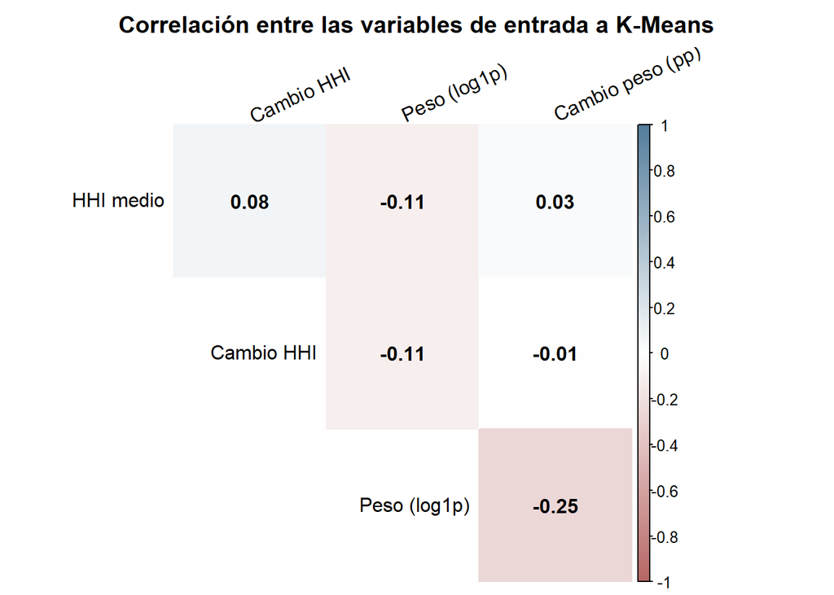

La tabla de momentos estadísticos muestra que en la participación media (%), la media (1.001 %) es mucho mayor que la mediana (0.203 %), la asimetría de 4.9 y la curtosis 25.5. Esto ocurre porque la distribución tiene una cola derecha extrema: tan solo dos capítulos (HS85 y HS84) concentran cerca del 39 % de las importaciones, mientras que la mayoría de los capítulos representa menos del 0.5 % cada uno.

Al aplicar peso_log = log1p(100 * participacion_media), la asimetría y la curtosis se reducen drásticamente. Esto demuestra por qué fue necesario transformar la variable: si metiéramos la participación cruda a K-Means, la distancia euclidiana estaría dominada únicamente por HS85 y HS84.

En HHI, tanto la media como la mediana son ligeramente negativas, reflejando un proceso generalizado de diversificación comercial, es decir, esta reducción responde a una menor dependencia del proveedor principal (top1) y a una menor asimetría en las cuotas de abastecimiento dentro de la mayoría de los capítulos.

[figure not shown]

La matriz de correlación indica que las relaciones lineales entre las cuatro variables de entrada son bajas o moderadas (ningún coeficiente supera $\vert{}r\vert{} = 0.45$). En particular, la correlación cercana a cero entre `Peso (log1p)` y `HHI medio` confirma que los capítulos donde México gasta más dinero no son necesariamente los más concentrados en un solo proveedo, por lo tanto, que no existan valores altos (>.80) valida que las cuatro variables aportan información distinta y no redundante al algoritmo K-Means.

El siguiente paso es ajustar varios números de grupos, comparar su separación e interpretar qué capítulos quedaron en cada uno.

```
## tibble [96 × 7] (S3: tbl_df/tbl/data.frame)
##  $ hs2                : chr [1:96] "01" "02" "03" "04" ...
##  $ capitulo           : chr [1:96] "Animals; live" "Meat and edible meat offal" "Fish and crustaceans, molluscs and other aquatic invertebrates" "Dairy produce; birds' eggs; natural honey; edible products of animal origin, not elsewhere specified or included" ...
##  $ hhi_medio          : num [1:96] 0.523 0.641 0.22 0.658 0.694 ...
##  $ cambio_hhi         : num [1:96] -0.0176 -0.147 0.0716 0.1002 -0.1792 ...
##  $ participacion_media: num [1:96] 0.000409 0.010472 0.001417 0.00465 0.000608 ...
##  $ cambio_peso_pp     : num [1:96] -0.01588 0.31769 -0.01385 0.05967 -0.00297 ...
##  $ peso_log           : num [1:96] 0.0401 0.7165 0.1325 0.3819 0.059 ...
```

Para determinar el número de grupos a utilizar en K-Means, se evaluaron soluciones entre (K=2) y (K=8). Para cada alternativa se calcularon dos métricas: la suma de cuadrados dentro de los clusters (WSS), que mide la dispersión interna de los grupos, y el coeficiente silhouette promedio, que evalúa qué tan bien separadas se encuentran las observaciones entre clusters.

Evaluación del número de clusters

| k | wss | silhouette |
| --- | --- | --- |
| 2 | 285.356 | 0.511 |
| 3 | 215.920 | 0.382 |
| 4 | 165.116 | 0.318 |
| 5 | 124.508 | 0.349 |
| 6 | 107.049 | 0.302 |
| 7 | 95.836 | 0.306 |
| 8 | 86.067 | 0.308 |

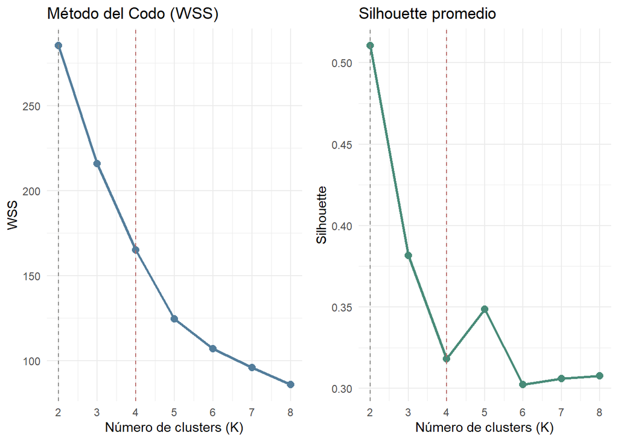

La WSS disminuye conforme aumenta el número de clusters, comportamiento esperado en K-Means debido a que una mayor cantidad de grupos permite reducir la variabilidad interna. Por ello, esta métrica no debe interpretarse de manera aislada.

El valor más alto de silhouette se obtuvo con (K=2), con un valor de 0.511, superior al observado para las demás alternativas. Esto sugiere que la solución de dos clusters presenta la mejor separación relativa entre grupos dentro de las opciones evaluadas.

Por esta razón, se seleccionó inicialmente (K=2) para ajustar el modelo final. No obstante, además del criterio estadístico, se revisará la composición y el perfil de los clusters para verificar que la solución tenga una interpretación económica adecuada.

```
##
##  1  2
##  7 89
```

```
##      hhi_medio   cambio_hhi   peso_log cambio_peso_pp
## 1 -0.109625529  0.062836053  2.6660474     -2.3261335
## 2  0.008622233 -0.004942161 -0.2096891      0.1829543
```

El modelo K-Means con (K=2) generó dos grupos de tamaños muy distintos: el cluster 1 contiene 7 capítulos HS2, mientras que el cluster 2 contiene 89 capítulos. Esta diferencia en tamaño no implica por sí misma que el agrupamiento sea incorrecto. Sin embargo, sugiere que el algoritmo está identificando un conjunto reducido de capítulos con características considerablemente distintas respecto al resto de las importaciones. Por ello, antes de interpretar los grupos como perfiles económicos definitivos, es necesario revisar qué capítulos integran cada cluster y cuáles variables explican principalmente esta separación.

Los centroides estandarizados muestran que la principal diferencia entre los dos clusters se encuentra en el peso económico de los capítulos. El cluster 1 presenta un valor de peso_log considerablemente superior al promedio, mientras que el cluster 2 se encuentra ligeramente por debajo.

El cluster 1 también presenta, en promedio, una reducción relativa en su participación dentro de las importaciones y un aumento ligeramente mayor de la concentración de proveedores. En contraste, el cluster 2 reúne a la mayoría de los capítulos y presenta valores más cercanos al promedio general.

Debido a que los centroides se encuentran expresados en unidades estandarizadas, estos valores muestran diferencias relativas respecto al promedio y no deben interpretarse directamente como porcentajes de participación o puntos del índice HHI, por lo que a continuación se examina la composición de cada grupo y su perfil promedio en escala original

Capítulos HS2 asignados a cada cluster

| cluster | hs2 | capitulo | hhi_medio | cambio_hhi | participacion_media | cambio_peso_pp |
| --- | --- | --- | --- | --- | --- | --- |
| 1 | 85 | Electrical machinery and equipment and parts thereof; sound recorders and reproducers; television image and sound recorders and reproducers, parts and accessories of such articles | 0.203 | -0.030 | 0.202 | -0.718 |
| 1 | 84 | Machinery and mechanical appliances, boilers, nuclear reactors; parts thereof | 0.208 | -0.031 | 0.167 | -0.266 |
| 1 | 27 | Mineral fuels, mineral oils and products of their distillation; bituminous substances; mineral waxes | 0.815 | 0.100 | 0.080 | -0.280 |
| 1 | 39 | Plastics and articles thereof | 0.445 | -0.074 | 0.055 | -0.581 |
| 1 | 90 | Optical, photographic, cinematographic, measuring, checking, medical or surgical instruments and apparatus; parts and accessories | 0.232 | 0.021 | 0.034 | -0.727 |
| 1 | 73 | Iron or steel articles | 0.309 | -0.036 | 0.020 | -0.393 |
| 1 | 29 | Organic chemicals | 0.373 | 0.023 | 0.020 | -0.302 |
| 2 | 87 | Vehicles; other than railway or tramway rolling stock, and parts and accessories thereof | 0.255 | -0.061 | 0.095 | 0.612 |
| 2 | 72 | Iron and steel | 0.209 | -0.056 | 0.028 | 0.811 |
| 2 | 76 | Aluminium and articles thereof | 0.250 | -0.105 | 0.016 | 0.251 |
| 2 | 40 | Rubber and articles thereof | 0.242 | -0.033 | 0.015 | -0.207 |
| 2 | 38 | Chemical products n.e.c. | 0.415 | -0.059 | 0.013 | 0.272 |
| 2 | 48 | Paper and paperboard; articles of paper pulp, of paper or paperboard | 0.463 | -0.159 | 0.013 | -0.271 |
| 2 | 10 | Cereals | 0.757 | 0.041 | 0.012 | 0.231 |
| 2 | 30 | Pharmaceutical products | 0.125 | -0.025 | 0.012 | 0.321 |
| 2 | 02 | Meat and edible meat offal | 0.641 | -0.147 | 0.010 | 0.318 |
| 2 | 12 | Oil seeds and oleaginous fruits; miscellaneous grains, seeds and fruit, industrial or medicinal plants; straw and fodder | 0.411 | -0.033 | 0.009 | 0.063 |
| 2 | 94 | Furniture; bedding, mattresses, mattress supports, cushions and similar stuffed furnishings; lamps and lighting fittings, n.e.c.; illuminated signs, illuminated name-plates and the like; prefabricated… | 0.291 | -0.016 | 0.008 | -0.194 |
| 2 | 33 | Essential oils and resinoids; perfumery, cosmetic or toilet preparations | 0.230 | -0.004 | 0.008 | 0.129 |
| 2 | 74 | Copper and articles thereof | 0.525 | -0.149 | 0.008 | 0.150 |
| 2 | 28 | Inorganic chemicals; organic and inorganic compounds of precious metals; of rare earth metals, of radio-active elements and of isotopes | 0.479 | 0.033 | 0.006 | -0.003 |
| 2 | 83 | Metal; miscellaneous products of base metal | 0.287 | -0.050 | 0.006 | -0.089 |
| 2 | 32 | Tanning or dyeing extracts; tannins and their derivatives; dyes, pigments and other colouring matter; paints, varnishes; putty, other mastics; inks | 0.371 | -0.050 | 0.005 | -0.087 |
| 2 | 61 | Apparel and clothing accessories; knitted or crocheted | 0.154 | 0.039 | 0.005 | 0.178 |
| 2 | 95 | Toys, games and sports requisites; parts and accessories thereof | 0.490 | -0.169 | 0.005 | -0.001 |
| 2 | 82 | Tools, implements, cutlery, spoons and forks, of base metal; parts thereof, of base metal | 0.179 | -0.005 | 0.005 | -0.116 |
| 2 | 04 | Dairy produce; birds’ eggs; natural honey; edible products of animal origin, not elsewhere specified or included | 0.658 | 0.100 | 0.005 | 0.060 |
| 2 | 44 | Wood and articles of wood; wood charcoal | 0.225 | -0.021 | 0.004 | -0.037 |
| 2 | 62 | Apparel and clothing accessories; not knitted or crocheted | 0.179 | -0.014 | 0.004 | 0.056 |
| 2 | 23 | Food industries, residues and wastes thereof; prepared animal fodder | 0.829 | -0.048 | 0.004 | -0.011 |

[output cut: 66 more lines]

La solución con $K=2$ asignó **7 capítulos al cluster 1 y 89 al cluster 2**. El primer grupo está integrado por equipo eléctrico (HS85), maquinaria mecánica (HS84), combustibles minerales (HS27), plásticos (HS39), instrumentos ópticos y médicos (HS90), artículos de hierro o acero (HS73) y productos químicos orgánicos (HS29).

Los capítulos del cluster 1 se caracterizan principalmente por tener una participación relativamente elevada dentro de las importaciones mexicanas y, en todos los casos, por haber reducido su participación entre el periodo inicial y final considerados. Sin embargo, no presentan un nivel homogéneo de concentración de proveedores: su HHI medio varía considerablemente entre capítulos.

Por lo tanto, la separación obtenida con $K=2$ parece estar determinada en mayor medida por la importancia económica y su cambio en el tiempo que por un patrón común de concentración. Esto debe considerarse al interpretar los clusters, ya que el objetivo del análisis es estudiar conjuntamente ambas dimensiones.

Perfil promedio de los clusters en unidades originales

| cluster | capitulos | hhi_medio | cambio_hhi | participacion_media_pct | cambio_peso_pp |
| --- | --- | --- | --- | --- | --- |
| 1 | 7 | 0.369 | -0.004 | 8.266 | -0.467 |
| 2 | 89 | 0.390 | -0.013 | 0.429 | 0.022 |

La comparación de los perfiles promedio muestra que la principal diferencia entre los dos clusters corresponde al peso económico de los capítulos dentro de las importaciones mexicanas. Los siete capítulos del cluster 1 representan, en promedio, 8.27% de las importaciones, mientras que los 89 capítulos del cluster 2 representan aproximadamente 0.43%.

En contraste, los niveles medios de concentración son similares entre ambos grupos: el HHI promedio es 0.369 en el cluster 1 y 0.390 en el cluster 2. Asimismo, los cambios promedio del HHI son relativamente pequeños en ambos casos.

Por lo tanto, aunque (K=2) presenta la mayor silhouette promedio entre las alternativas evaluadas, la separación obtenida está determinada principalmente por la importancia económica de los capítulos y no genera una diferenciación clara en términos de concentración de proveedores. Debido a ello, resulta conveniente analizar también una solución con un mayor número de clusters antes de seleccionar el modelo definitivo.

Por lo tanto, replicamos el procedimiento anterior utilizando $K=4$ para evaluar si un mayor número de grupos permite separar los capítulos tanto por su peso económico como por su nivel y cambio de concentración.

```
##
##  1  2  3  4
##  7 46 32 11
```

Centroides en variables estandarizadas (K = 4)

| hhi_medio | cambio_hhi | peso_log | cambio_peso_pp |
| --- | --- | --- | --- |
| -0.110 | 0.063 | 2.666 | -2.326 |
| -0.738 | -0.055 | -0.077 | 0.247 |
| 0.829 | -0.668 | -0.295 | 0.096 |
| 0.743 | 2.136 | -0.517 | 0.167 |

A diferencia de $K=2$ (donde solo peso_log y cambio_peso_pp se alejaban de cero mientras hhi_medio quedaba casi en 0 en ambos grupos), en la tabla de centroides de $K=4$ cada grupo se especializa en una dimensión distinta:

1. Este grupo tiene el centroide con peso_log muy elevado (es decir, capítulos gigantes de las importaciones mexicanas).
2. Otro grupo destaca por tener el centroide con hhi_medio altamente positivo y/o cambio_hhi positivo (capítulos de alta concentración).
3. Un tercer grupo presenta cambio_hhi marcadamente negativo (capítulos que redujeron su concentración y diversificaron proveedores).
4. El ultimo grupo agrupa a los capítulos de peso pequeño/intermedio y estabilidad relativa (valores cercanos al promedio 0 en cambio de peso y concentración moderada).

Una vez revisados los centroides estandarizados, asignamos a cada capítulo HS2 su número de cluster correspondiente en `datos_clusters4` y los ordenamos de mayor a menor participación media dentro de cada grupo para identificar qué sectores concretos integran cada perfil:

Capítulos HS2 asignados a cada cluster (k=4)

| cluster | hs2 | capitulo | hhi_medio | cambio_hhi | participacion_media | cambio_peso_pp |
| --- | --- | --- | --- | --- | --- | --- |
| 1 | 85 | Electrical machinery and equipment and parts thereof; sound recorders and reproducers; television image and sound recorders and reproducers, parts and accessories of such articles | 0.203 | -0.030 | 0.202 | -0.718 |
| 1 | 84 | Machinery and mechanical appliances, boilers, nuclear reactors; parts thereof | 0.208 | -0.031 | 0.167 | -0.266 |
| 1 | 27 | Mineral fuels, mineral oils and products of their distillation; bituminous substances; mineral waxes | 0.815 | 0.100 | 0.080 | -0.280 |
| 1 | 39 | Plastics and articles thereof | 0.445 | -0.074 | 0.055 | -0.581 |
| 1 | 90 | Optical, photographic, cinematographic, measuring, checking, medical or surgical instruments and apparatus; parts and accessories | 0.232 | 0.021 | 0.034 | -0.727 |
| 1 | 73 | Iron or steel articles | 0.309 | -0.036 | 0.020 | -0.393 |
| 1 | 29 | Organic chemicals | 0.373 | 0.023 | 0.020 | -0.302 |
| 2 | 87 | Vehicles; other than railway or tramway rolling stock, and parts and accessories thereof | 0.255 | -0.061 | 0.095 | 0.612 |
| 2 | 72 | Iron and steel | 0.209 | -0.056 | 0.028 | 0.811 |
| 2 | 76 | Aluminium and articles thereof | 0.250 | -0.105 | 0.016 | 0.251 |
| 2 | 40 | Rubber and articles thereof | 0.242 | -0.033 | 0.015 | -0.207 |
| 2 | 38 | Chemical products n.e.c. | 0.415 | -0.059 | 0.013 | 0.272 |
| 2 | 30 | Pharmaceutical products | 0.125 | -0.025 | 0.012 | 0.321 |
| 2 | 12 | Oil seeds and oleaginous fruits; miscellaneous grains, seeds and fruit, industrial or medicinal plants; straw and fodder | 0.411 | -0.033 | 0.009 | 0.063 |
| 2 | 94 | Furniture; bedding, mattresses, mattress supports, cushions and similar stuffed furnishings; lamps and lighting fittings, n.e.c.; illuminated signs, illuminated name-plates and the like; prefabricated… | 0.291 | -0.016 | 0.008 | -0.194 |
| 2 | 33 | Essential oils and resinoids; perfumery, cosmetic or toilet preparations | 0.230 | -0.004 | 0.008 | 0.129 |
| 2 | 83 | Metal; miscellaneous products of base metal | 0.287 | -0.050 | 0.006 | -0.089 |
| 2 | 32 | Tanning or dyeing extracts; tannins and their derivatives; dyes, pigments and other colouring matter; paints, varnishes; putty, other mastics; inks | 0.371 | -0.050 | 0.005 | -0.087 |
| 2 | 61 | Apparel and clothing accessories; knitted or crocheted | 0.154 | 0.039 | 0.005 | 0.178 |
| 2 | 82 | Tools, implements, cutlery, spoons and forks, of base metal; parts thereof, of base metal | 0.179 | -0.005 | 0.005 | -0.116 |
| 2 | 44 | Wood and articles of wood; wood charcoal | 0.225 | -0.021 | 0.004 | -0.037 |
| 2 | 62 | Apparel and clothing accessories; not knitted or crocheted | 0.179 | -0.014 | 0.004 | 0.056 |
| 2 | 31 | Fertilizers | 0.146 | 0.017 | 0.004 | 0.016 |
| 2 | 70 | Glass and glassware | 0.340 | -0.049 | 0.003 | -0.028 |
| 2 | 15 | Animal, vegetable or microbial fats and oils and their cleavage products; prepared edible fats; animal or vegetable waxes | 0.186 | -0.143 | 0.003 | 0.008 |
| 2 | 64 | Footwear; gaiters and the like; parts of such articles | 0.254 | 0.000 | 0.003 | 0.079 |
| 2 | 71 | Natural, cultured pearls; precious, semi-precious stones; precious metals, metals clad with precious metal, and articles thereof; imitation jewellery; coin | 0.239 | -0.163 | 0.003 | 0.026 |
| 2 | 22 | Beverages, spirits and vinegar | 0.227 | -0.017 | 0.002 | -0.075 |
| 2 | 54 | Man-made filaments; strip and the like of man-made textile materials | 0.276 | -0.015 | 0.002 | -0.055 |
| 2 | 35 | Albuminoidal substances; modified starches; glues; enzymes | 0.277 | -0.072 | 0.002 | -0.005 |

[output cut: 66 more lines]

Al revisar los capítulos que integran cada uno de los cuatro grupos en sus unidades originales, se observa una separación más clara que la obtenida con $K=2$:

Podemos observar que el cluster 1 está encabezado por los capítulos de mayor volumen en las importaciones mexicanas, comenzando por equipo eléctrico (`HS85`, con una participación media de `0.202` o 20.2% del total) y maquinaria mecánica (`HS84`, con `0.167` o 16.7%), seguidos por combustibles minerales (`HS27`). En la tabla se aprecia que tanto `HS85` como `HS84` mantienen una concentración de proveedores baja (`hhi_medio` de `0.203` y `0.208`, respectivamente) y registraron una ligera disminución en su concentración (`cambio_hhi` de `-0.030` y `-0.031`), además de una reducción en su peso relativo dentro del total de socios identificados (`cambio_peso_pp` de `-0.718` y `-0.266` puntos porcentuales). Como se vio antes, dentro de este grupo de gran tamaño el caso opuesto en concentración es `HS27` (combustibles), que sí depende fuertemente de un solo proveedor.

Para resumir el comportamiento general de estos cuatro grupos sin depender de la lectura individual de los 96 capítulos, a continuación se calcula el promedio de cada indicador por cluster.

Perfil promedio de los clusters en unidades originales (k=4)

| cluster | capitulos | hhi_medio | cambio_hhi | participacion_media_pct | cambio_peso_pp |
| --- | --- | --- | --- | --- | --- |
| 1 | 7 | 0.369 | -0.004 | 8.266 | -0.467 |
| 2 | 46 | 0.259 | -0.019 | 0.614 | 0.034 |
| 3 | 32 | 0.534 | -0.096 | 0.278 | 0.005 |
| 4 | 11 | 0.519 | 0.258 | 0.097 | 0.018 |

[figure not shown]

### Limitaciones e interpretación de los resultados

El análisis utiliza el valor comercial en dólares corrientes (`primaryValue`). Por ello, los cambios observados en la participación o en el HHI de capítulos como combustibles (`HS27`) o cereales (`HS10`) pueden estar influidos por variaciones internacionales de precios y no reflejan necesariamente cambios equivalentes en las cantidades físicas importadas.

Los códigos de dos dígitos (HS2) reúnen sectores completos (como toda la electrónica o todos los vehículos) y no productos individuales. Por eso, aunque un sector completo tenga sus compras bien repartidas entre varios países, dentro de él todavía pueden existir productos muy específicos (a nivel de cuatro o seis dígitos) que dependan de un solo proveedor. Además, estos números reflejan cómo se distribuye el dinero de las compras, pero no indican qué tan fácil sería cambiar de vendedor en la práctica ni explican por sí solos las causas de esos cambios.

### Conclusiones

Por otro lado, los resultados son consistentes con la hipótesis planteada: la concentración de proveedores no cambió de la misma manera en todos los capítulos. Mientras que una parte amplia de los capítulos manufactureros intermedios redujo su HHI entre 2015–2017 y 2023–2025, otros capítulos de alta concentración mantuvieron o incrementaron el peso de su socio principal.

Por ultimo, aunque el coeficiente *silhouette* promedio alcanzó su valor máximo en $K=2$ (`0.511`), el análisis de perfiles demostró que dos grupos separan a los capítulos casi exclusivamente por su escala económica (`8.27%` frente a `0.43%` de participación media), dejando niveles de HHI similares en ambos grupos. Ampliar el agrupamiento a $K=4$ permitió distinguir perfiles que separan tanto el peso económico como el nivel y la dirección del cambio en el HHI.